# Nagelkerke, MSGB & Datasets

Antoine Lizee

04/28/2015

# Intro

The goal is to compare different way of using the Nagelkerke. We’ll learn on the way that modeling should not be done on the testing set, that performance metrics are biaised and that the MSGB computed from the WTCCC2 cohort is “overfitted” if used on a smaller dataset.

The code can sometimes be lengthy, so don’t hesitate to glaze over the details to focus on the results. I put all the code in the same document so it’s self sufficient, but some of it is not really relevant to our problem.

## Initialization

### Import data & packages

[Code is not shown, open the Rmd file to see it if interested]

### General purpose functions

[Code is not shown, open the Rmd file to see it if interested]

# Nagelkerke on GeneMSA

## A small intro on Nagelkerke R2

Nagelkerke is a “pseudo” R-squared (R2). These R2 are different definitions of the classic “OLS” R2 (ordinary least squares), in order to accomodate different models or capture the same idea differently. The Nagelkerke R2 (NR2) is a normalisation of the Cox & Snell R2 (so it can be between 0 and 1 like classic R2). The formula is:

$R^2_{Nagel} = \frac{1 - \left\{ \frac{L(M_{intercept})}{L(M_{model})} \right\}^{2/N}} {1 - L(M_{intercept})^{2/N}}$

It basically compares the **likelihood** of the model that we are testing with the likelihhod the null model, which is the logistic regression with only the intercept[^1]. As a result, we cannot use the classic formulation “*explains xx% of the variance of …*”" as this R-squared is not about variance.

Let’s compute the Nagelkerke for the MSGB of GeneMSA:

```r
# Calculation of Nagelkerke R2.
fit <- glm(factor(Score$Pheno)~Score$Score, family="binomial")
NagelkerkeR2(fit)
```

```
## $N
## [1] 1839
##
## $R2
## [1] 0.08202
```

We get `8.2e^-2` as a Nagelkerke R2, which seems pretty small. What is happening?

## Comparison of in-data vs out-data models

We will here compute the Nagelkerke R2 for several settings, as an exploration:

```r
# Let's construct the list with the different models:
fits <- list(
  # Classic MSGB, we take the "Score".
  MSGB = glm(Y ~ X, family = "binomial", data = data.frame(Y = Score$Pheno, X = Score$Score)),
  # Let's calculate the MSGB by hand, doing the sum:
  SumGB = glm(Y ~ X, family = "binomial", data = data.frame(Y = Score$Pheno,
                                                            X = apply(Score[,5:(ncol(Score)-1)], 1, sum))),
  # What if we give all the GBs directly as predictors:
  AllGB = glm(Y ~ ., family = "binomial", data = data.frame(Y = Score$Pheno, Score[,5:(ncol(Score)-1)]))
  )

# Print the NR2:
sapply(fits, NagelkerkeR2)
```

```
##    MSGB    SumGB   AllGB
## N  1839    1839    1839
## R2 0.08202 0.08202 0.1528
```

So here is the catch: If we compute the MSGB that comes from WTCC2 by directly summing all the Global Burdens (GBs), we explain less of what is happening in Gene_MSA, so we have a smaller value of NR2 compared to when we let the model figure out by itself the best coefficients for every SNP. The difference we see above is really between the refitted model (when we do `glm(Y~.)`) and the initial MSGB (when we do `glm(Y~sum(GBs))`).

**Remark:** For the in-data model, we use *AllGB* as name, and we pass as predictors the individual global burdens (GB), but passing the genotypes (ex: number of alleles) **would not make a difference** since we create a new model with new cofficients. Since the results would be identical, we use the GBs for practical reasons (same dataset as the MSGB).

Furthermore, it is not about the number of predictors included in the model. To see this, we can compute another NR2 with only one predictor (like the sums earlier) but computed from the new model that we will call MSGB2:

```r
fits$MSGB2 <- glm(Y ~ ., family = "binomial", data = data.frame(Y = Score$Pheno, X = predict(fits$AllGB)))
sapply(fits, NagelkerkeR2) # Notice how SumGB and AllGB are different but AllGB and AllGBSummed are the same.
```

```
##    MSGB    SumGB   AllGB  MSGB2
## N  1839    1839    1839   1839
## R2 0.08202 0.08202 0.1528 0.1528
```

Finally, if we have only a few SNPs in the models, we get a smaller NR2 in both cases:

```r
fits <- c(fits, list(
  # Same analysis for 5 SNPs only:
  SumGB5 = glm(Y ~ X, family = "binomial", data = data.frame(Y = Score$Pheno, X = apply(Score[,5:10], 1, sum))),
  AllGB5 = glm(Y ~ ., family = "binomial", data = data.frame(Y = Score$Pheno, Score[,5:10]))
  ))
sapply(fits, NagelkerkeR2)
```

```
##    MSGB    SumGB   AllGB  MSGB2  SumGB5   AllGB5
## N  1839    1839    1839   1839   1839     1839
## R2 0.08202 0.08202 0.1528 0.1528 0.004811 0.008761
```

But this is only the tip of the iceberg. The NR2 of $8.2e^-2$ still seems too low.

# Nagelkerke R-squared for different numbers of SNPs

## Preparation of the datasets

We want to construct datasets with SNPs that have no signal. We are doing it with two different methods, but future will tell that it doesn’t matter.

```r
# Get the SNP meta data out of the data frame:
SNPBurden <- Score[,4:(ncol(Score)-1)]
# Prepare random datasets:
SNPBurdenRandom2 <- SNPBurdenRandom <- SNPBurden
# Create a "model" of SNPs that is close to what we see (not necessary to understand exactly)
SNPBurdenRandom[,2:ncol(SNPBurden)] <- lapply(
  runif(n = ncol(SNPBurden)-1, min = 0, max = 0.25),
  function(r) {
    p = max(min(rnorm(1, 0.5, 0.2), 0.95), 0.05)
    sample(0:2, size = nrow(SNPBurden), replace = T, prob = c(p^2, p*(1-p), (1-p)^2))*r
    })
# Just shuffling:
SNPBurdenRandom2[,2:ncol(SNPBurden)] <- lapply(SNPBurden[,-1],
                                               function(v) v[sample(length(v))])
```

## In-data Model

This setting is (unfortunately) common in the litterature: we use R2 to assess the “explanation power” of a model, from the data the model is fitted on.

Here, if we build the model from the GeneMSA data like earlier (MSGB2), the more predictors we put, the better the model gets, and the higher the R-squared. This is a classic behavior with R-squared: even noise will increase its value.

This is easily tested with our fake datasets that have SNPs with random signals:

```r
NagelGBs <- function(n, data = SNPBurden) {
  # Funcion to compute a Nagel from a number of predictors taken randomly from the datasets
  SNPs <- sample(x = 2:ncol(data), size = n)
  NagelkerkeR2(glm(Y ~ ., family = "binomial", data = data.frame(Y = data$Pheno, data[,SNPs])))
  }
```

```r
# Compute different Nagelkerke with different numbers of predictors, random and not.
# **Takes a while** or get loaded.
computeOrLoad( "nPredNagels.RData", # Loaded file if computed
               "nPredNagels",       # Loaded object
               {
                 # Computing NR2 for submodels with n GB predictors
                 nPredNagels <- do.call(rbind, lapply(2:(ncol(Score)-7),
                                                      function(n) data.frame(n = n,
                                                                             type = "GBs",
                                                                             NR2 = replicate(10, NagelGBs(n)$R2))))
                 # Computing NR2 for submodels with n random predictors
                 nPredNagels <- rbind(nPredNagels,
                                      do.call(rbind, lapply(2:(ncol(Score)-7),
                                                            function(n) data.frame(n = n,
                                                                                   type = "random",
                                                                                   NR2 = replicate(10, NagelGBs(n, SNPBurdenRandom)$R2)))))
                 # Second random dataset
                 nPredNagels <- rbind(nPredNagels,
                                      do.call(rbind, lapply(2:(ncol(Score)-7),
                                                            function(n) data.frame(n = n,
                                                                                   type = "random2",
                                                                                   NR2 = replicate(10, NagelGBs(n, SNPBurdenRandom2)$R2)))))
                 }
               )
```

```
## Loading from RData file 'nPredNagels.RData'...
```

Lets’ plot it:

```
## geom_smooth: method="auto" and size of largest group is <1000, so using loess. Use 'method = x' to change the smoothing method.
```

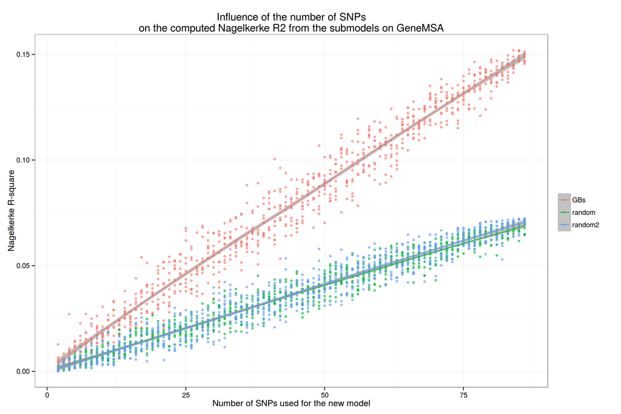

```r
qplot(data = nPredNagels, x = n, y = NR2, group = type, color = type, geom=c("point", "smooth"), shape = I(20), alpha = I(0.6), width = I(3)) +
  theme_bw() +
  labs(x = "Number of SNPs used for the new model",
       y = "Nagelkerke R-square",
       title = "Influence of the number of SNPs\non the computed Nagelkerke R2 from the submodels on GeneMSA",
       colour = NULL)
```

Now, instead of taking a random subset of predictors (the SNPs), we order them thanks to a stepwise regression that chooses at each step the predictor that has the best contribution to the Nagelkerke R2:

```r
# Function to create a stepwise regression on NR2:
NagelstepGBs <- function(data = SNPBurden) {
  indexes <- 2:ncol(data)
  taken <- c()
  n <- 0
  df <- NULL
  while(length(indexes > 0)) {
    nagels_n <- sapply(indexes, function(i) {
      NagelkerkeR2(glm(Y ~ .,
                       family = "binomial",
                       data = data.frame(Y = data$Pheno, data[, c(taken, i), drop = FALSE]))
                   )$R2
      })
    nagel_max_ind <- which.max(nagels_n)
    taken <- c(taken, indexes[nagel_max_ind])
    df <- rbind(df, data.frame(n = n <- n+1, chosen = indexes[nagel_max_ind], NR2 = nagels_n[nagel_max_ind]))
    indexes <- indexes[-nagel_max_ind]
    }
  return(df)
  }

# **Takes a bigger while**, but get loaded if already done.
computeOrLoad("stepwiseInNagels.RData",
              "NagelStepsIn", {
                NagelStepsIn <- data.frame(NagelstepGBs(SNPBurden), type = "GBs")
                NagelStepsIn <- rbind(NagelStepsIn, data.frame(NagelstepGBs(SNPBurdenRandom2), type = "random"))
                })
```

```
## Loading from RData file 'stepwiseInNagels.RData'...
```

[figure not shown]

```r
qplot(data = NagelStepsIn, x = n, y = NR2, group = type, color = type,
      geom=c("point"), shape = I(20), alpha = I(0.6), width = I(3)) +
  theme_bw() +
  labs(x = "number of SNPs used for the reduced MSGB",
       y = "Nagelkerke R-square",
       title = "Nagelkerke stepwise regression\nof submodels including SNPs",
       colour = NULL)
```

We can see several things:

- The R2 “plateau”s for the GB-based model, implying that the contribution of the last SNPs is not significant.
- The best random SNP yields a significant increase in NR2 by chance (it is expected).
- The NR2, by considering as null model the intercept-only model, is a biaised estimator of goodness fit. Indeed, a more accurate null model with shuffled predictors gets a value significantly greater than zero.

## Out-data Model

Now, we are in a place where we can try to do all we’ve done above, but with the “out-data” model, i.e. the real MSGB, computed from WTCCC2. We will use each time here the sum of the GBs instead of letting the predictors be fitted at best by the model. So in term of code, we will reuse the same chunks as in the “in-data” part above, but with this small change:

```r
#Instead of:
NagelkerkeR2(glm(Y ~ .,
                 family = "binomial",
                 data = data.frame(Y = data$Pheno, data[, c(taken, i), drop = FALSE]))
             )$R2
})
#We'll use:
NagelkerkeR2(glm(Y ~ X,
                 family = "binomial",
                 data = data.frame(Y = data$Pheno, X = apply(data[, c(taken, i), drop = FALSE], 1, sum)))
             )$R2
})
```

So the “sub-models” tested now are partial MSGBs where we sum the GBs of a subset of selected SNPs.

[Full code not shown]

```
## Loading from RData file 'stepwiseNagels.RData'...
```

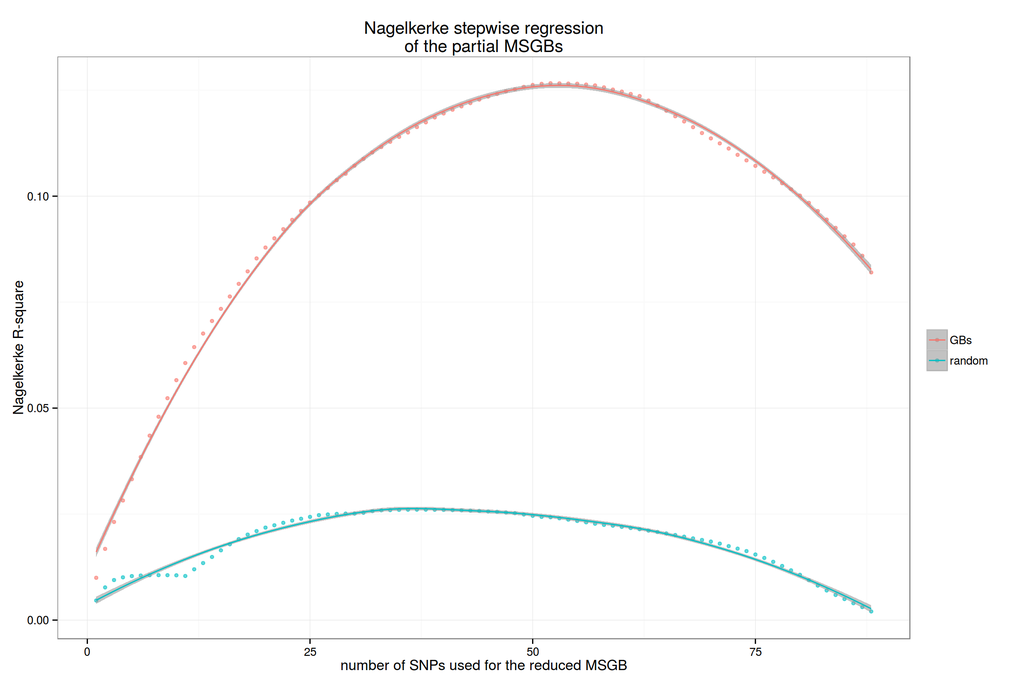

What we see now is quite interesting:

```r
max(NagelSteps$NR2)
```

```
## [1] 0.1266
```

# WTCC2

Finally, let’s have a quick look at the WTCCC2 dataset itself.

```r
computeOrLoad("WTCCC2NR2.RData",
              "WTCCC2NR2s",
              {
                # Loading the different datasets
                load(file.path(inputPath, "MSGB_data.Rdata"))
                MSGBCC <- factor(subjectsScores$PHENOTYPE, labels=c('controls', 'cases'))
                MSGB <- apply(subjectsDoses, 1, sum)
                WTCCC2NR2s <- c(
                  # Let see the NR2 for the MSGB:
                  "MSGB" = NagelkerkeR2(glm(MSGBCC ~ MSGB, family = "binomial"))$R2,
                  # What if we refit the model?
                  "InModelGBs" = NagelkerkeR2(glm(Y~., data.frame(Y = MSGBCC, subjectsDoses), family = "binomial"))$R2,
                  # Getting the SNP data should yield the same result:
                  "InModelSNPs" = NagelkerkeR2(glm(Y~., data.frame(Y = MSGBCC, subjectsSNPs), family = "binomial"))$R2
                  )
                })
```

```
## Loading from RData file 'WTCCC2NR2.RData'...
```

```r
print(WTCCC2NR2s)
```

```
##        MSGB  InModelGBs InModelSNPs
##     0.09389     0.10958     0.10958
```

A couple of surprises: